# Dívida e resultado primário

Cinco economias emergentes · Fiscal Monitor, abril/2026

Diretoria de Pesquisa Aplicada

## A pergunta da reunião

**Como dívida bruta e saldo primário se distribuem entre os cinco países, na mesma edição do Fiscal Monitor?**

O recorte é Brasil, México, Chile, Índia e Indonésia. Os gráficos usam governo geral e % do PIB. A decisão exige olhar **estoque e fluxo** antes de falar em sustentabilidade.

## Uma base, duas medidas

| Medida | Código do CSV | Leitura |
| --- | --- | --- |
| Dívida bruta do governo geral | `GGXWDG_NGDP` | Estoque em % do PIB |
| Saldo primário do governo geral | `GGXONLB_NGDP` | Fluxo antes de juros; positivo = superávit |

## A dívida no tempo

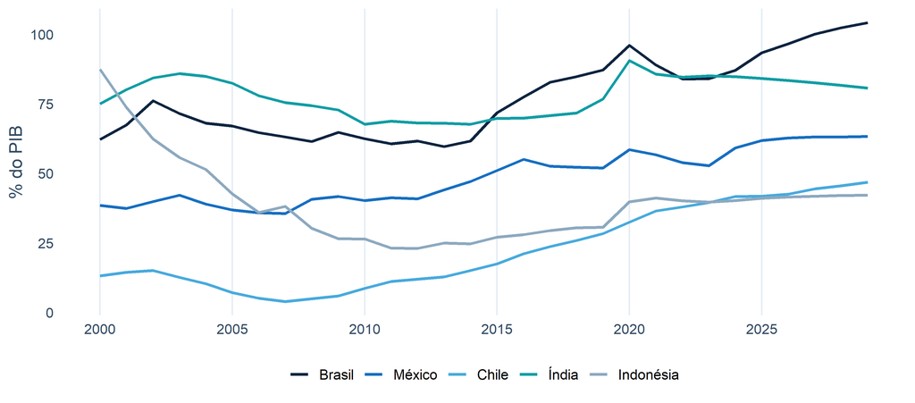

Figura 1: Dívida bruta do governo geral, % do PIB. Fonte: CSV-contrato, FM abril/2026.

## Dívida em 2025: mesma edição

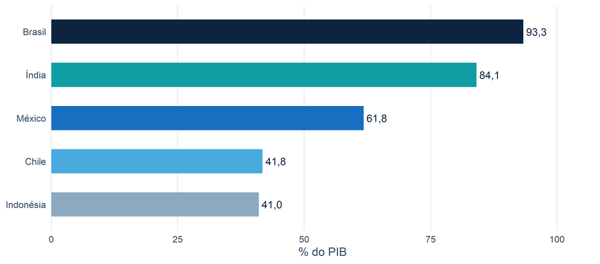

Figura 2: Dívida bruta em 2025, % do PIB. FM abril/2026; valores arredondados só no gráfico.

## O primário no tempo

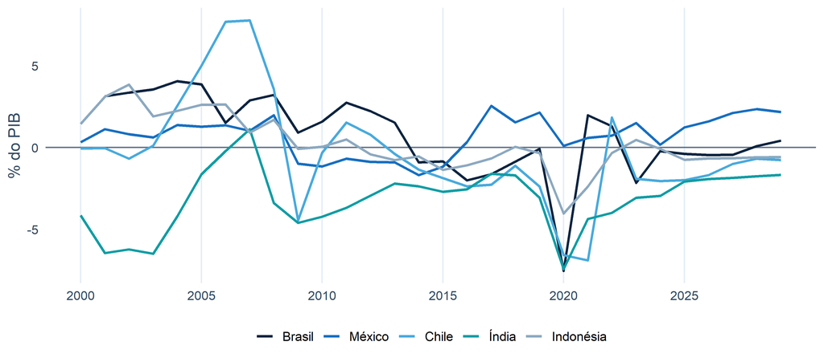

Figura 3: Saldo primário do governo geral, % do PIB. Acima de zero = superávit.

## Primário em 2025: onde está o zero?

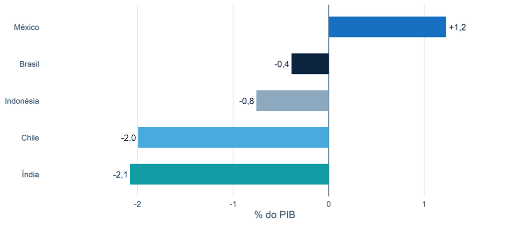

Figura 4: Saldo primário em 2025, % do PIB. FMI, mesma edição e ano.

## Brasil: o que os dois números dizem?

- Dívida bruta em 2025: **93,3% do PIB**, segundo o indicador do FMI.
- Saldo primário em 2025: **-0,4% do PIB**. Negativo indica déficit na convenção do FMI.
- A comparação usa o **mesmo ano, setor, edição e unidade** nos cinco países.

Esses dois números descrevem uma posição e um fluxo. Sozinhos, não demonstram sustentabilidade da trajetória.

## Estoque e fluxo lado a lado

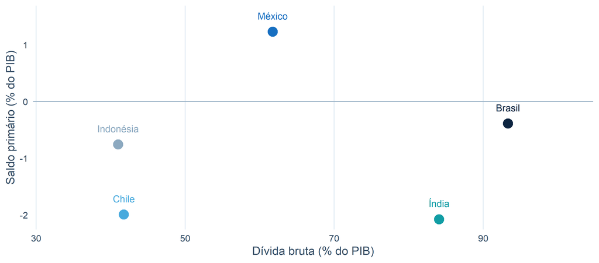

Figura 5: Dívida bruta (x) e saldo primário (y) em 2025. Cada ponto é um país do mesmo CSV.

## Leitura para a Diretoria

**Constatação · 2025:** Brasil com dívida bruta de 93,3% do PIB e saldo primário de -0,4% do PIB no recorte do FMI.

**Limite:** o CSV não marca cada ponto como observado ou estimado. 2026–2029 são o horizonte projetado; a Índia usa ano fiscal.

**Encaminhamento:** conferir cobertura e status. Sustentabilidade exigiria hipóteses de juros, crescimento e primário.

## Fonte, reprodução e referência visual

- **Dados:** `02-dados-fiscal-monitor/data/processed/fm_weo_cache.csv`; `FM-2026-04`; dois códigos do contrato.
- **Reproduzir:** `baixar_fm.R --offline` → CSV → Quarto. Conferir com `validar_contrato.py`.
- **Método:** [Fiscal Monitor, abril/2026](https://www.imf.org/en/publications/fm/issues/2026/04/15/fiscal-monitor-april-2026) e [notas metodológicas](https://www.imf.org/-/media/files/publications/fiscal-monitor/2026/april/english/msa.pdf).
- **Inspiração visual:** [OCDE, *OECD Economic Outlook, Volume 2026 Issue 1*](https://www.oecd.org/en/publications/oecd-economic-outlook-volume-2026-issue-1_2d1956f0-en.html). Paleta e hierarquia adaptadas, sem marca ou fotografia.